# 203 Assignment 1

## Introduction

This assignment is going to use the principles of energy balance to examine how changing properties of urban environments alter the temperature of urban landscapes. In urban areas, the distribution of materials such as asphalt and concrete has been shown to lead to higher air temperatures compared to rural counterparts. This is known as the urban heat island (UHI) effect. High temperatures can be harmful to the health of residents, and in order to mitigate the UHI cities adopt strategies like increasing tree cover to increase shade and cooling, or increasing the reflectivity, also called albedo, with white paint. However, these strategies are not always evenly distributed throughout a city and may create environmental inequity. Read more about this phenomena [here](https://docs.google.com/document/d/1NUJATMo7KnmC3PpyFRdxo9HWH0F-zQxUDKiIW6pX7pY/edit#heading=h.z1slrwcvefnj).

We’ve assembled a dataset that captures a snapshot of average midday temperatures in August, the amount of vegetation, and a host of social/economic data across each neighborhood in the county of Los Angeles. The temperature data is from the Landsat satellite’s surface thermal data and was acquired in the Spring (April) and Summer (August) of 2020. The vegetation data is characterized by the Normalized Difference Vegetation Index (NDVI), and is taken from similar dates. [NDVI](https://earthobservatory.nasa.gov/features/MeasuringVegetation/measuring_vegetation_2.php) is a measure of “greenness” and higher values of NDVI indicate a greater amount of green vegetation within each neighborhood. The neighborhood information is collated from the incredibly awesome Mapping LA project developed by the [LA Times](http://maps.latimes.com/neighborhoods), which is worth checking out. See a description of each column in the dataset at this [link](https://docs.google.com/spreadsheets/d/1Hh-hMt5RuXA3lBYX8G16T3334zXQfbFnJzCxh3qbDsw/edit#gid=0)

### Mapping Los Angeles County

In this assignment, we’ll be exploring surface temperatures of different neighborhoods in Los Angeles County. To get a better idea of the spatial patterns within the county, check out the plots below, and make a few of your own.

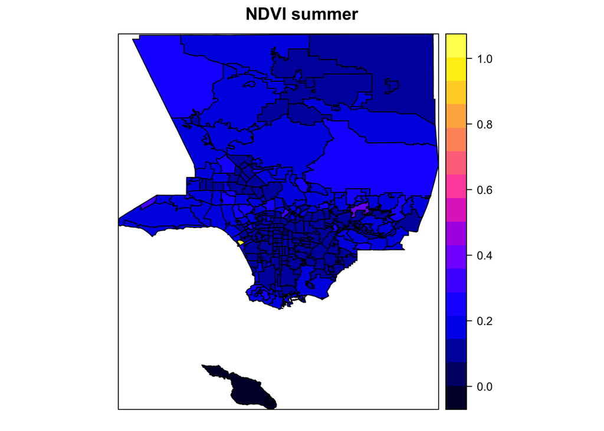

```r
# load shapefile - this contains map of neighborhoods
losang <- shapefile("CPT/data/ESM203_F2020_Ass1.shp")

# view spatial NDVI
spplot(losang, 'NDVI_SUMME', main="NDVI summer")
```

```r
## chose a different variable and plot it here (can check other variables by typing 'names(losang)' in the console)
```

We can also look at the data as a dataframe, which allows us to see if there are any correlations between variables.

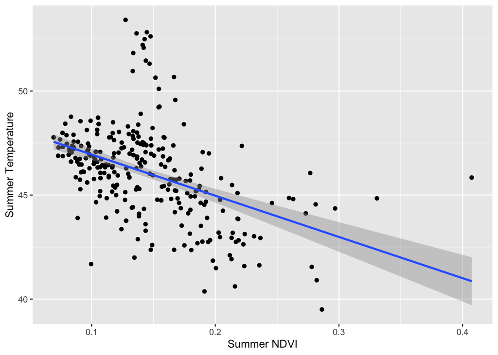

```r
# load in data as a CSV
LA_nbhds <- read.csv("CPT/data/ESM203_F2020_Ass1.csv")

LA_nbhds %>%
  dplyr::filter(NDVI_SUMMER > 0 & NDVI_SUMMER < 1) %>%
  ggplot() + geom_jitter(aes(x=NDVI_SUMMER, y=TEMP_SUMMER)) +
  geom_smooth(aes(x=NDVI_SUMMER, y=TEMP_SUMMER), method=lm) +
  labs(x = "Summer NDVI", y="Summer Temperature")
```

### Part I: Forming a hypothesis

Is there a relationship between NDVI and temperature? Why do you think this exists? Form a hypothesis.

In equation form, the surface energy balance looks like this. In a list below, describle each term in the equation and what they represent.
$$Q_{av} = L_{out} + k_H(\Delta T) + k_E(\Delta VPD)$$

could also ask about all three different parameters

sensitivity analysis: relative humidity, albedo.

can we vary RH from 0-1 and see how temp changes? then plot that - set up SA with albedo as an example for them - have them look at parameters and figure out which parameters to be able to change. Can you figure it out from an equation?

direct them to test RH then have plot with RH on x axis

## Surface Energy Balance - Solving for surface temperature

The chunck below consists of functions needed to do the assignment.

```r
# the following functions are needed to solve the surface energy balance and calculate latent heat
# run this chunk to load the functions into R

# Tetens eq. to solve for saturated vapor pressure (used in LE eq.)
sat_vp <- function(T){
  e <- 0.61078*exp(17.27*T/(T+237.3))
  return(e)
  }

# surface energy balance returns surface temperature
# input is surface temperature, represented as x (in celsius)
seb <- function(x, veg, alpha=0.15, eps=0.95){
  k_E = veg*50
  RH_s = veg
  L_inc = 0.9 * sigma * (T_a+273.15)^4  # W/m^2, incoming longwave radiation
Q_av = 0.9 * (K_inc*(1-alpha) + L_inc) # W/m^2

  k = Q_av
  L = eps*sigma*(x+273.15)^4
  Qh = k_H*(x-T_a)
  Qe = k_E*(RH_s*sat_vp(x) - RH*sat_vp(T_a))
  val = -k + L + Qh + Qe
  return(val)
}


## returns bar plot of the different fluxes
plot_fluxes <- function(veg){
  range=c(1,100)
  x <- uniroot.all(seb, range, veg=veg)
  L_inc = 0.9 * sigma * (T_a+273.15)^4  # W/m^2, incoming   longwave radiation
  Q_av = 0.9 * (K_inc*(1-alpha) + L_inc) # W/m^2
  k = Q_av
  k_E = veg*50
  RH_s = veg
  L = eps*sigma*(x+273.15)^4
  Qh = k_H*(x-T_a)
  Qe = k_E*(RH_s*sat_vp(x) - RH*sat_vp(T_a))
  fluxes <- data.frame(flux=c("k","L","Qh","Qe"), value=c(k,L,Qh,Qe))
  plot <- ggplot(fluxes) + geom_col(aes(x=flux, y=value, fill=flux))
  return(plot)
}
```

Run the code below to assign the variables and calculate the surface temperature.

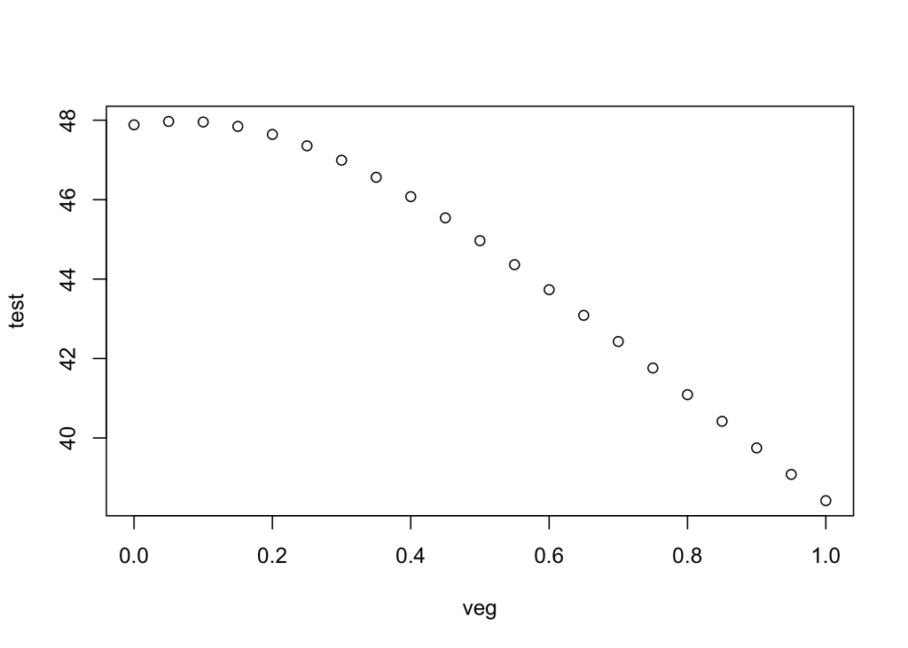

```r
T_a = 28 # ambient atm temp in Celsius
alpha = 0.15 # albedo of the surface
eps = 0.95 # emissivity of the surface
sigma = 5.6704*10^-8 #W/m^2/K^4 stefan-boltzmann constant
k_H = 21 # Sensible heat conductivity [J/deg-C]
#k_E = 100 # [J/kPa] Latent heat conductivity (only present if surface is wet)
RH = 0.4 # Relative humidity of atmosphere, [0-1]
#RH_s = 0.25 # Relative humidity of the surface (assume 1 is wet/irrigated, 0 is dry)
K_inc = 800 # W/m^2, incoming shortwave radiation (this changes during night)


## Run the below code to solve for surface temperature
# temp_s is surface temperature
range = c(0,100)
test_veg <- function(veg){
  temp_s = uniroot.all(seb, range, veg=veg)
  return(temp_s)
}

# quick SA for veg parameter
veg <- seq(0,1, by=0.05)
test <- sapply(X=veg, FUN=test_veg)
plot(veg, test) # plot veg v. temp
```

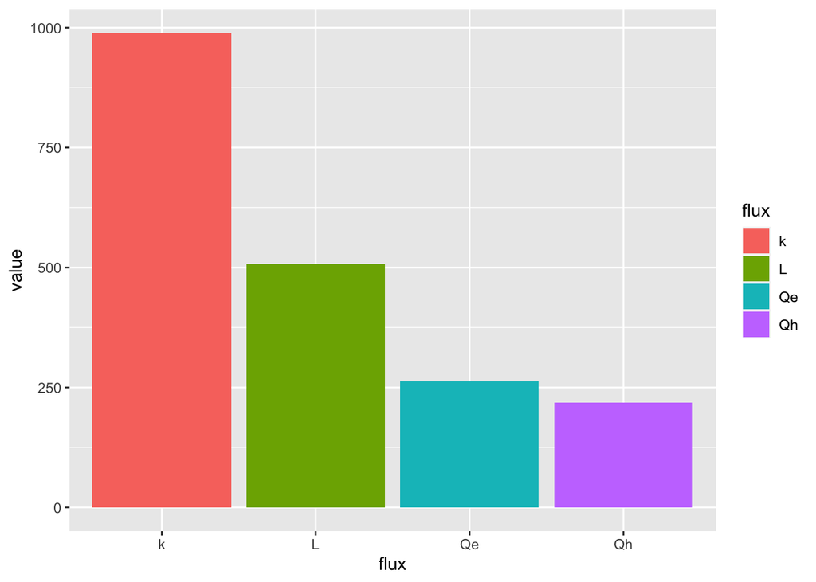

```r
# plot_fluxes shows a bar plot of the different energy fluxes. Change veg between 0 to 1 to see how the latent and sensible energy change
plot_fluxes(veg=1)
```

a couple of discussion questions about: - white pain on pavement - how does this change seb and temps? - veg and temp - how does this affect people living there?

Remember the NDVI. v. temp plot above? Now it’s your turn to explore the data set (LA_nbhds) and create plots. You can use anything you’ve learned from 206 so far to explore and summarize the data. Create at least one plot that includes NDVI or temperature on the x-axis, and a socio-economic variable on the y-axis. You can copy and paste the code from above, but also be creative! Then answer the reflection questions below.

```r
## plot here
```

1. Based on your plot(s) what relationship exists? Write a short (1-2 paragraph max) reaction/response to your findings, focusing on what they imply for issues related to environmental management, planning, and/or environmental justice. While your response should refer to the specifics of your plots/presentation, you do not need to do an exhaustive analysis or find citations to support your inference.
2. For this entire assignment: Share a thought or lesson that clicked for you. What was the most interesting part?